# Introduction to Signature Variability Analysis with sigvar

Maike Morrison

15 December 2023

# 1 Introduction

The R package *sigvar* implements **sig**nature **var**iability analysis, a framework for the analysis of mutational signature activities within and across cancer samples. This R package accompanies the paper [“Variability of mutational signatures is a footprint of carcinogens’’ by Morrison et al.](https://doi.org/10.1101/2023.11.23.23298821); please refer to the paper for more details on the methods presented in this package.

The *sigvar* package contains two core functions to perform signature variability analysis:

- `sigvar`: Compute the within-sample diversity and across-sample heterogeneity of mutational signature activity in one or multiple populations of samples
- `sigboot`: Use bootstrapping to statistically compare the within-sample diversity and across-sample heterogeneity of the mutational signature activity between two or more groups of samples

*sigvar* also includes accessory functions for the visualization of mutational signature data, such as:

- `plot_SBS_spectrum`: Plot the SBS mutational spectrum of one or more samples of mutational signatures
- `plot_signature_prop`: Plot the relative activities of mutational signatures in each sample as a stacked bar plot
- `plot_dots`: Plot the mean mutational signature contributions of one or more groups of samples

## 1.1 Installation

You can install the development version of sigvar from [GitHub](https://github.com/MaikeMorrison/sigvar) with:

```r
install.packages("devtools") # run only if devtools not already installed
devtools::install_github("MaikeMorrison/sigvar",
                         dependencies = TRUE, build_vignettes = TRUE)
```

After installation, you can access this introductory vignette at an time by running:

```r
vignette("tutorial", package = "sigvar")
```

## 1.2 Overview

We begin the tutorial by explaining what types of data are required to use the *sigvar* R package (Data specifications). We then conduct an example of signature variability analysis (Example analysis), using data from [Moody et al. (2021)](https://www.nature.com/articles/s41588-021-00928-6) to explore the within-sample diversity and across-sample heterogeneity of mutational signature activities for esophageal squamous cell carcinoma (ESCC) samples from eight countries which vary dramatically in their ESCC incidences. We begin our example analysis by introducing the data (Example data) and demonstrating the data visualization functions of *sigvar* (Visualize mutational signature activities). We then perform Signature variability analysis, visualize the results, and use Bootstrapping to determine the statistical significance of differences in SVA results between countries.

# 2 Data specifications

To use the *sigvar* package, your data must be in the form of a data frame, matrix, or tibble with rows corresponding to samples and columns corresponding to either metadata (on the left-hand side) or relative activities of mutational signatures (on the right hand side). You can read the data into R using functions such as `read.csv`, `data.table::fread`, or `readxl::read_xlsx`, depending on the file type.

Each row of your matrix must correspond to one sample. If your matrix contains metadata, you must specify `K`, the number of signatures, and the signatures must all be on the right-hand side of the matrix. The relative activities of all `K` signatures must sum to 1 for each sample.

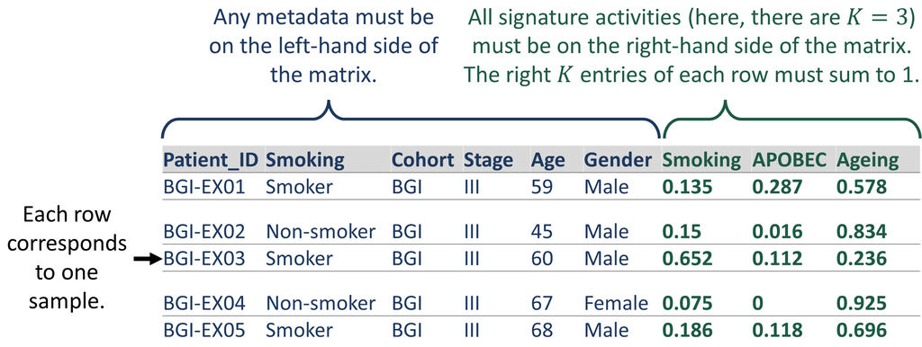

Your matrix may contain samples from multiple groups you would like to analyze separately. In this case, you must provide the name of the column specifying the group each sample belongs to as the `group` parameter of the `sigvar` or `sigboot` functions. For example, to separately analyze the smokers and non-smokers in the matrix pictured above, we would specify `group = "Smoking"`.

## 2.1 Optional: signature similarity matrix

If you would like to perform SVA while accounting for the similarity among mutational signatures, you must provide the `sigvar` or `sigboot` functions with a similarity matrix, `S`, which must also be a data frame, matrix, or tibble. Entry `S[i,j]` corresponds to the similarity of the mutational spectra of signatures `i` and `j`. All diagonal elements must equal 1 (i.e., `S[i,j]=1` when `i==j`), since each signature is identical to itself. All off-diagonal elements must be between 0 and 1, inclusive. In our analyses, we use cosine similarity matrices, where we define entry `S[i,j]` as the cosine similarity between the mutational spectra of signatures `i` and `j`.

| Type | SBS1 | SBS2 | SBS3 | SBS4 | SBS5 | SBS6 | SBS7a | SBS7b | SBS7c | SBS7d | SBS8 | SBS9 | SBS10a | SBS10b | SBS10c | SBS10d | SBS11 | SBS12 | SBS13 | SBS14 | SBS15 | SBS16 | SBS17a | SBS17b | SBS18 | SBS19 | SBS20 | SBS21 | SBS22 | … |
| --- | --- | --- | --- | --- | --- | --- | --- | --- | --- | --- | --- | --- | --- | --- | --- | --- | --- | --- | --- | --- | --- | --- | --- | --- | --- | --- | --- | --- | --- | --- |
| A[C>A]A | 0.001 | 0.000 | 0.021 | 0.042 | 0.012 | 0.000 | 0.000 | 0.002 | 0.005 | 0.000 | 0.044 | 0.001 | 0.002 | 0.000 | 0.004 | 0.010 | 0.000 | 0.005 | 0.002 | 0.001 | 0.001 | 0.016 | 0.002 | 0.001 | 0.052 | 0.001 | 0.001 | 0.000 | 0.006 | … |
| A[C>A]C | 0.002 | 0.000 | 0.016 | 0.033 | 0.009 | 0.001 | 0.000 | 0.000 | 0.001 | 0.001 | 0.047 | 0.004 | 0.002 | 0.006 | 0.015 | 0.018 | 0.001 | 0.001 | 0.001 | 0.013 | 0.000 | 0.003 | 0.001 | 0.000 | 0.016 | 0.001 | 0.001 | 0.002 | 0.000 | … |
| A[C>A]G | 0.000 | 0.000 | 0.002 | 0.016 | 0.002 | 0.000 | 0.000 | 0.000 | 0.000 | 0.000 | 0.005 | 0.000 | 0.000 | 0.000 | 0.001 | 0.001 | 0.000 | 0.001 | 0.000 | 0.000 | 0.000 | 0.001 | 0.000 | 0.000 | 0.003 | 0.000 | 0.000 | 0.000 | 0.001 | … |
| A[C>A]T | 0.001 | 0.000 | 0.012 | 0.030 | 0.007 | 0.000 | 0.000 | 0.001 | 0.002 | 0.004 | 0.047 | 0.003 | 0.017 | 0.000 | 0.013 | 0.014 | 0.000 | 0.001 | 0.000 | 0.083 | 0.001 | 0.011 | 0.000 | 0.000 | 0.021 | 0.001 | 0.001 | 0.001 | 0.002 | … |
| A[C>G]A | 0.002 | 0.000 | 0.020 | 0.007 | 0.010 | 0.000 | 0.000 | 0.000 | 0.001 | 0.001 | 0.004 | 0.005 | 0.000 | 0.000 | 0.000 | 0.000 | 0.000 | 0.001 | 0.004 | 0.000 | 0.000 | 0.002 | 0.001 | 0.000 | 0.002 | 0.003 | 0.009 | 0.000 | 0.002 | … |
| A[C>G]C | 0.001 | 0.000 | 0.012 | 0.003 | 0.006 | 0.000 | 0.000 | 0.000 | 0.000 | 0.003 | 0.003 | 0.002 | 0.000 | 0.000 | 0.000 | 0.000 | 0.000 | 0.001 | 0.001 | 0.000 | 0.000 | 0.002 | 0.001 | 0.000 | 0.003 | 0.002 | 0.001 | 0.001 | 0.000 | … |
| A[C>G]G | 0.000 | 0.000 | 0.000 | 0.001 | 0.002 | 0.000 | 0.000 | 0.001 | 0.000 | 0.001 | 0.000 | 0.001 | 0.000 | 0.000 | 0.000 | 0.000 | 0.000 | 0.000 | 0.000 | 0.000 | 0.000 | 0.001 | 0.000 | 0.000 | 0.002 | 0.001 | 0.000 | 0.000 | 0.000 | … |
| A[C>G]T | 0.001 | 0.000 | 0.017 | 0.004 | 0.010 | 0.000 | 0.000 | 0.000 | 0.002 | 0.003 | 0.006 | 0.006 | 0.000 | 0.000 | 0.001 | 0.000 | 0.001 | 0.001 | 0.004 | 0.000 | 0.000 | 0.012 | 0.000 | 0.000 | 0.004 | 0.002 | 0.004 | 0.000 | 0.000 | … |
| A[C>T]A | 0.025 | 0.000 | 0.014 | 0.009 | 0.033 | 0.064 | 0.000 | 0.001 | 0.001 | 0.003 | 0.007 | 0.008 | 0.001 | 0.001 | 0.005 | 0.001 | 0.026 | 0.006 | 0.007 | 0.012 | 0.005 | 0.002 | 0.001 | 0.001 | 0.009 | 0.028 | 0.050 | 0.002 | 0.002 | … |
| A[C>T]C | 0.006 | 0.001 | 0.012 | 0.004 | 0.018 | 0.023 | 0.017 | 0.038 | 0.008 | 0.001 | 0.003 | 0.005 | 0.001 | 0.005 | 0.005 | 0.002 | 0.146 | 0.002 | 0.000 | 0.010 | 0.007 | 0.004 | 0.002 | 0.000 | 0.005 | 0.014 | 0.013 | 0.004 | 0.000 | … |
| A[C>T]G | 0.371 | 0.000 | 0.003 | 0.001 | 0.006 | 0.123 | 0.000 | 0.001 | 0.001 | 0.001 | 0.003 | 0.005 | 0.006 | 0.000 | 0.013 | 0.001 | 0.008 | 0.000 | 0.000 | 0.027 | 0.077 | 0.003 | 0.000 | 0.000 | 0.013 | 0.002 | 0.014 | 0.008 | 0.001 | … |
| A[C>T]T | 0.009 | 0.002 | 0.012 | 0.004 | 0.022 | 0.021 | 0.007 | 0.011 | 0.007 | 0.033 | 0.013 | 0.007 | 0.003 | 0.008 | 0.006 | 0.003 | 0.110 | 0.002 | 0.000 | 0.016 | 0.002 | 0.006 | 0.001 | 0.000 | 0.008 | 0.037 | 0.013 | 0.000 | 0.001 | … |
| A[T>A]A | 0.001 | 0.000 | 0.005 | 0.009 | 0.007 | 0.000 | 0.002 | 0.002 | 0.012 | 0.000 | 0.019 | 0.013 | 0.000 | 0.002 | 0.004 | 0.002 | 0.000 | 0.005 | 0.000 | 0.001 | 0.002 | 0.023 | 0.001 | 0.000 | 0.002 | 0.001 | 0.001 | 0.003 | 0.064 | … |
| A[T>A]C | 0.002 | 0.001 | 0.007 | 0.004 | 0.007 | 0.001 | 0.001 | 0.000 | 0.003 | 0.001 | 0.021 | 0.003 | 0.000 | 0.000 | 0.014 | 0.003 | 0.000 | 0.003 | 0.000 | 0.000 | 0.001 | 0.008 | 0.001 | 0.000 | 0.001 | 0.000 | 0.005 | 0.006 | 0.007 | … |
| A[T>A]G | 0.001 | 0.000 | 0.010 | 0.012 | 0.009 | 0.000 | 0.001 | 0.002 | 0.000 | 0.004 | 0.023 | 0.003 | 0.000 | 0.000 | 0.001 | 0.001 | 0.000 | 0.003 | 0.001 | 0.000 | 0.001 | 0.009 | 0.000 | 0.000 | 0.003 | 0.001 | 0.000 | 0.000 | 0.060 | … |
| A[T>A]T | 0.000 | 0.000 | 0.006 | 0.004 | 0.006 | 0.002 | 0.004 | 0.008 | 0.050 | 0.041 | 0.025 | 0.019 | 0.007 | 0.003 | 0.071 | 0.022 | 0.000 | 0.003 | 0.001 | 0.002 | 0.009 | 0.011 | 0.001 | 0.001 | 0.008 | 0.001 | 0.026 | 0.002 | 0.003 | … |
| A[T>C]A | 0.001 | 0.000 | 0.016 | 0.008 | 0.046 | 0.002 | 0.000 | 0.001 | 0.000 | 0.004 | 0.010 | 0.020 | 0.001 | 0.009 | 0.018 | 0.005 | 0.001 | 0.073 | 0.002 | 0.013 | 0.004 | 0.241 | 0.000 | 0.000 | 0.002 | 0.003 | 0.011 | 0.017 | 0.025 | … |
| A[T>C]C | 0.003 | 0.000 | 0.008 | 0.001 | 0.013 | 0.001 | 0.000 | 0.000 | 0.001 | 0.004 | 0.005 | 0.011 | 0.004 | 0.001 | 0.009 | 0.003 | 0.001 | 0.040 | 0.000 | 0.006 | 0.002 | 0.013 | 0.013 | 0.000 | 0.002 | 0.001 | 0.005 | 0.010 | 0.001 | … |
| A[T>C]G | 0.000 | 0.000 | 0.012 | 0.005 | 0.038 | 0.004 | 0.000 | 0.001 | 0.001 | 0.009 | 0.007 | 0.014 | 0.002 | 0.001 | 0.017 | 0.008 | 0.000 | 0.070 | 0.000 | 0.012 | 0.000 | 0.064 | 0.000 | 0.000 | 0.002 | 0.002 | 0.019 | 0.004 | 0.008 | … |
| A[T>C]T | 0.006 | 0.000 | 0.017 | 0.002 | 0.038 | 0.000 | 0.001 | 0.002 | 0.003 | 0.051 | 0.015 | 0.029 | 0.003 | 0.000 | 0.013 | 0.006 | 0.001 | 0.064 | 0.001 | 0.006 | 0.001 | 0.136 | 0.008 | 0.001 | 0.004 | 0.002 | 0.000 | 0.026 | 0.001 | … |
| A[T>G]A | 0.000 | 0.000 | 0.004 | 0.001 | 0.004 | 0.000 | 0.000 | 0.000 | 0.012 | 0.004 | 0.002 | 0.045 | 0.002 | 0.000 | 0.003 | 0.007 | 0.000 | 0.002 | 0.000 | 0.000 | 0.000 | 0.011 | 0.001 | 0.001 | 0.001 | 0.002 | 0.000 | 0.000 | 0.002 | … |
| A[T>G]C | 0.000 | 0.000 | 0.003 | 0.000 | 0.003 | 0.000 | 0.000 | 0.001 | 0.001 | 0.003 | 0.001 | 0.007 | 0.001 | 0.000 | 0.001 | 0.001 | 0.000 | 0.001 | 0.000 | 0.003 | 0.000 | 0.004 | 0.001 | 0.004 | 0.001 | 0.002 | 0.000 | 0.000 | 0.000 | … |
| A[T>G]G | 0.000 | 0.000 | 0.006 | 0.001 | 0.008 | 0.000 | 0.000 | 0.001 | 0.001 | 0.011 | 0.005 | 0.005 | 0.000 | 0.001 | 0.001 | 0.001 | 0.000 | 0.001 | 0.000 | 0.001 | 0.000 | 0.005 | 0.001 | 0.001 | 0.002 | 0.002 | 0.000 | 0.000 | 0.003 | … |
| A[T>G]T | 0.000 | 0.000 | 0.004 | 0.000 | 0.005 | 0.000 | 0.000 | 0.001 | 0.000 | 0.014 | 0.001 | 0.024 | 0.009 | 0.000 | 0.013 | 0.005 | 0.000 | 0.001 | 0.000 | 0.011 | 0.004 | 0.008 | 0.012 | 0.069 | 0.002 | 0.002 | 0.000 | 0.000 | 0.000 | … |
| C[C>A]A | 0.000 | 0.000 | 0.022 | 0.080 | 0.007 | 0.002 | 0.000 | 0.001 | 0.000 | 0.014 | 0.040 | 0.005 | 0.003 | 0.001 | 0.017 | 0.010 | 0.001 | 0.005 | 0.001 | 0.016 | 0.041 | 0.010 | 0.000 | 0.000 | 0.073 | 0.001 | 0.037 | 0.000 | 0.002 | … |
| C[C>A]C | 0.002 | 0.000 | 0.025 | 0.079 | 0.006 | 0.004 | 0.000 | 0.002 | 0.003 | 0.003 | 0.038 | 0.002 | 0.000 | 0.003 | 0.010 | 0.015 | 0.001 | 0.004 | 0.001 | 0.019 | 0.005 | 0.009 | 0.001 | 0.000 | 0.019 | 0.001 | 0.098 | 0.003 | 0.004 | … |
| C[C>A]G | 0.000 | 0.000 | 0.003 | 0.025 | 0.003 | 0.002 | 0.000 | 0.000 | 0.002 | 0.000 | 0.003 | 0.001 | 0.000 | 0.000 | 0.002 | 0.001 | 0.000 | 0.001 | 0.000 | 0.001 | 0.000 | 0.002 | 0.000 | 0.000 | 0.012 | 0.000 | 0.007 | 0.002 | 0.000 | … |
| C[C>A]T | 0.000 | 0.000 | 0.015 | 0.069 | 0.006 | 0.009 | 0.000 | 0.001 | 0.013 | 0.000 | 0.033 | 0.003 | 0.017 | 0.008 | 0.044 | 0.018 | 0.000 | 0.001 | 0.000 | 0.258 | 0.028 | 0.002 | 0.000 | 0.000 | 0.036 | 0.000 | 0.251 | 0.019 | 0.000 | … |
| C[C>G]A | 0.000 | 0.000 | 0.019 | 0.008 | 0.007 | 0.000 | 0.000 | 0.000 | 0.000 | 0.001 | 0.005 | 0.001 | 0.000 | 0.000 | 0.000 | 0.000 | 0.000 | 0.001 | 0.006 | 0.000 | 0.000 | 0.004 | 0.001 | 0.000 | 0.001 | 0.002 | 0.000 | 0.000 | 0.001 | … |
| C[C>G]C | 0.000 | 0.000 | 0.014 | 0.007 | 0.009 | 0.000 | 0.000 | 0.001 | 0.002 | 0.000 | 0.005 | 0.002 | 0.000 | 0.000 | 0.000 | 0.000 | 0.000 | 0.001 | 0.001 | 0.000 | 0.000 | 0.004 | 0.000 | 0.000 | 0.002 | 0.002 | 0.000 | 0.000 | 0.001 | … |

[output cut: 66 more lines]

In order to convert a matrix of signature definitions such as this matrix to a pairwise cosine similarity matrix, we recommend using the `cossim` function in the *sigvar* R package. Below we provide example code to both generate a similarity matrix from a matrix of mutational signature definitions and verify that its entries are between 0 and 1, and that its diagonal elements equal 1.

```r
# Exclude the first column, "Type", which defines each  mutational type
cosmic_sbs_sim = sigvar::cossim(as.matrix(sigvar::COSMIC3.3.1_SBS[,-1]))

# View the first 10 rows and 5 columns of the similarity matrix
cosmic_sbs_sim[1:10, 1:5]
```

```
#>             SBS1       SBS2       SBS3       SBS4      SBS5
#> SBS1  1.00000000 0.02031489 0.05372626 0.02361321 0.1942669
#> SBS2  0.02031489 1.00000000 0.09833748 0.04469572 0.2526434
#> SBS3  0.05372626 0.09833748 1.00000000 0.63777474 0.7928402
#> SBS4  0.02361321 0.04469572 0.63777474 1.00000000 0.3801633
#> SBS5  0.19426687 0.25264337 0.79284023 0.38016329 1.0000000
#> SBS6  0.77021158 0.06403593 0.21684573 0.08186122 0.4138381
#> SBS7a 0.04804510 0.71515949 0.21073504 0.08209717 0.3603178
#> SBS7b 0.06974539 0.26959035 0.34612947 0.14372094 0.4300020
#> SBS7c 0.02369922 0.05861210 0.32534537 0.12121403 0.2550711
#> SBS7d 0.01457751 0.07276100 0.27448994 0.08036521 0.3331761
```

```r
# Confirm that the diagonal elements of the matrix are all equal to 1
all(diag(cosmic_sbs_sim) == 1)
```

```
#> [1] TRUE
```

```r
# Confirm that all elements are non-negative
all(cosmic_sbs_sim >= 0)
```

```
#> [1] TRUE
```

```r
# Confirm that no elements exceed 1
all(cosmic_sbs_sim <= 1)
```

```
#> [1] TRUE
```

When including a cosine similarity matrix in `sigvar` or `sigboot`, it is important that the ordering of signatures in the similarity matrix matches the ordering in your signature activity matrix. You should reorder the rows and columns of your similarity matrix to match your activity matrix:

```r
# Suppose this is the list of signatures included
# in your relative activity matrix:
sigs = c("SBS95", "SBS10a", "SBS5", "SBS1", "SBS17b")

# Re-order the rows and columns of the similarity matrix
sim_reordered = cosmic_sbs_sim[sigs, sigs]

sim_reordered
```

```
#>             SBS95     SBS10a       SBS5       SBS1     SBS17b
#> SBS95  1.00000000 0.38204509 0.44330584 0.06556141 0.01485958
#> SBS10a 0.38204509 1.00000000 0.13864361 0.01788389 0.01455829
#> SBS5   0.44330584 0.13864361 1.00000000 0.19426687 0.09887873
#> SBS1   0.06556141 0.01788389 0.19426687 1.00000000 0.00211760
#> SBS17b 0.01485958 0.01455829 0.09887873 0.00211760 1.00000000
```

# 3 Example analysis

```r
library(sigvar)
library(dplyr)
library(tidyr)
library(ggplot2)
library(patchwork)
```

## 3.1 Example data

In this example, we apply signature variability analysis (SVA) to data from [Moody et al. (2021)](https://www.nature.com/articles/s41588-021-00928-6). This data set contains 552 esophageal squamous cell carcinoma (ESCC) samples collected across eight countries which vary dramatically in their incidence of ESCC. Moody et al. (2021) reported the activities of 43 SBS, DBS, and ID mutational signatures for each sample.

The example data set, `ESCC_sig_activity`, has 552 rows, each corresponding to one sample, and 46 columns:

- `Country`: the country in which each sample was collected
- `Incidence_Level`: the ESCC incidence level of the country where the sample was collected
- `Sample`: the identifier for each sample
- `SBS1`, `SBS2`, …, `ID17`: the relative activities of the 43 mutational signatures reported by Moody et al.

The rightmost 43 entries of each row sum to 1, since these entries correspond to the relative activities of all mutational signatures.

You can explore the structure of this data using the following functions:

```r
# open the data set in a new window
View(ESCC_sig_activity)

# view the structure of the data set
str(ESCC_sig_activity)
```

Here are the first 40 rows and the first 20 columns of the relative abundance matrix, `ESCC_sig_activity`:

| Country | Incidence_Level | Sample | SBS1 | SBS2 | SBS3 | SBS4 | SBS5 | SBS8 | SBS10a | SBS10b | SBS12 | SBS13 | SBS14 | SBS15 | SBS16 | SBS17a | SBS17b | SBS18 | SBS20 |
| --- | --- | --- | --- | --- | --- | --- | --- | --- | --- | --- | --- | --- | --- | --- | --- | --- | --- | --- | --- |
| Kenya | High | PD37727a | 0.1479571 | 0.0000000 | 0 | 0 | 0 | 0.0000000 | 0 | 0 | 0 | 0.0000000 | 0 | 0.0000000 | 0.0000000 | 0.1267247 | 0.2507703 | 0.3060281 | 0 |
| Kenya | High | PD37728a | 0.1563596 | 0.2072368 | 0 | 0 | 0 | 0.0000000 | 0 | 0 | 0 | 0.2342105 | 0 | 0.0000000 | 0.0000000 | 0.0000000 | 0.0000000 | 0.3085526 | 0 |
| Kenya | High | PD37729a | 0.0000000 | 0.1957034 | 0 | 0 | 0 | 0.0000000 | 0 | 0 | 0 | 0.2642043 | 0 | 0.0000000 | 0.0000000 | 0.0000000 | 0.0000000 | 0.0000000 | 0 |
| Kenya | High | PD37730a | 0.1645137 | 0.2344225 | 0 | 0 | 0 | 0.0000000 | 0 | 0 | 0 | 0.2621581 | 0 | 0.0000000 | 0.0000000 | 0.0000000 | 0.0000000 | 0.0000000 | 0 |
| Kenya | High | PD37731a | 0.0000000 | 0.3172216 | 0 | 0 | 0 | 0.0000000 | 0 | 0 | 0 | 0.6565411 | 0 | 0.0000000 | 0.0000000 | 0.0000000 | 0.0000000 | 0.0000000 | 0 |
| Kenya | High | PD37733a | 0.1344803 | 0.2122607 | 0 | 0 | 0 | 0.0000000 | 0 | 0 | 0 | 0.3423795 | 0 | 0.0000000 | 0.0000000 | 0.0000000 | 0.1097650 | 0.0000000 | 0 |
| Kenya | High | PD37734a | 0.1736811 | 0.1416716 | 0 | 0 | 0 | 0.0000000 | 0 | 0 | 0 | 0.1926497 | 0 | 0.0000000 | 0.0000000 | 0.0000000 | 0.0000000 | 0.4078245 | 0 |
| Kenya | High | PD37735a | 0.1995916 | 0.2003573 | 0 | 0 | 0 | 0.0000000 | 0 | 0 | 0 | 0.2197550 | 0 | 0.0000000 | 0.0000000 | 0.0000000 | 0.0000000 | 0.2942828 | 0 |
| Kenya | High | PD37737a | 0.1001535 | 0.0934382 | 0 | 0 | 0 | 0.0000000 | 0 | 0 | 0 | 0.2927859 | 0 | 0.0000000 | 0.0000000 | 0.0000000 | 0.0000000 | 0.4173062 | 0 |
| Kenya | High | PD37738a | 0.2138171 | 0.0000000 | 0 | 0 | 0 | 0.0000000 | 0 | 0 | 0 | 0.1813971 | 0 | 0.0000000 | 0.0000000 | 0.0000000 | 0.0000000 | 0.4971054 | 0 |
| Kenya | High | PD37739a | 0.3500224 | 0.0000000 | 0 | 0 | 0 | 0.0000000 | 0 | 0 | 0 | 0.0000000 | 0 | 0.0000000 | 0.0000000 | 0.0000000 | 0.0000000 | 0.4541797 | 0 |
| Kenya | High | PD37740a | 0.0772918 | 0.4086627 | 0 | 0 | 0 | 0.0000000 | 0 | 0 | 0 | 0.4172414 | 0 | 0.0000000 | 0.0000000 | 0.0000000 | 0.0530698 | 0.0000000 | 0 |
| Kenya | High | PD37741a | 0.0926210 | 0.2165535 | 0 | 0 | 0 | 0.0000000 | 0 | 0 | 0 | 0.3831837 | 0 | 0.0000000 | 0.0000000 | 0.0000000 | 0.0000000 | 0.2550909 | 0 |
| Kenya | High | PD37742a | 0.1912434 | 0.1464098 | 0 | 0 | 0 | 0.0000000 | 0 | 0 | 0 | 0.1653240 | 0 | 0.0000000 | 0.0000000 | 0.0000000 | 0.0914186 | 0.3264448 | 0 |
| Kenya | High | PD37743a | 0.1390852 | 0.2651543 | 0 | 0 | 0 | 0.0000000 | 0 | 0 | 0 | 0.5057642 | 0 | 0.0000000 | 0.0000000 | 0.0000000 | 0.0000000 | 0.0000000 | 0 |
| Kenya | High | PD37745a | 0.1999146 | 0.1255874 | 0 | 0 | 0 | 0.0000000 | 0 | 0 | 0 | 0.1631781 | 0 | 0.0000000 | 0.0000000 | 0.0000000 | 0.0000000 | 0.3583938 | 0 |
| Kenya | High | PD37746a | 0.1407636 | 0.1658311 | 0 | 0 | 0 | 0.0000000 | 0 | 0 | 0 | 0.1912842 | 0 | 0.0000000 | 0.0000000 | 0.0000000 | 0.0000000 | 0.4330891 | 0 |
| Kenya | High | PD37747a | 0.0680806 | 0.0000000 | 0 | 0 | 0 | 0.0000000 | 0 | 0 | 0 | 0.0000000 | 0 | 0.0000000 | 0.0000000 | 0.0000000 | 0.0000000 | 0.0000000 | 0 |
| Kenya | High | PD37748a | 0.2138456 | 0.1366437 | 0 | 0 | 0 | 0.0000000 | 0 | 0 | 0 | 0.0855382 | 0 | 0.0000000 | 0.0000000 | 0.0000000 | 0.0000000 | 0.4367524 | 0 |
| Kenya | High | PD37749a | 0.0872017 | 0.0882863 | 0 | 0 | 0 | 0.0000000 | 0 | 0 | 0 | 0.1633406 | 0 | 0.0000000 | 0.0000000 | 0.0000000 | 0.0379610 | 0.5442516 | 0 |
| Kenya | High | PD37751a | 0.4005771 | 0.0000000 | 0 | 0 | 0 | 0.0000000 | 0 | 0 | 0 | 0.1930745 | 0 | 0.0000000 | 0.0000000 | 0.0000000 | 0.0000000 | 0.0000000 | 0 |
| Kenya | High | PD37752a | 0.3857291 | 0.0000000 | 0 | 0 | 0 | 0.0000000 | 0 | 0 | 0 | 0.0000000 | 0 | 0.0000000 | 0.0000000 | 0.0000000 | 0.0000000 | 0.0000000 | 0 |
| Kenya | High | PD37753a | 0.1916347 | 0.2031583 | 0 | 0 | 0 | 0.0000000 | 0 | 0 | 0 | 0.2902262 | 0 | 0.0000000 | 0.0000000 | 0.0000000 | 0.1438327 | 0.0000000 | 0 |
| Kenya | High | PD37754a | 0.0968917 | 0.0458735 | 0 | 0 | 0 | 0.0000000 | 0 | 0 | 0 | 0.0370847 | 0 | 0.0000000 | 0.0000000 | 0.0000000 | 0.0000000 | 0.2006431 | 0 |
| Kenya | High | PD37756a | 0.1114923 | 0.2620926 | 0 | 0 | 0 | 0.0000000 | 0 | 0 | 0 | 0.2631218 | 0 | 0.0000000 | 0.1989708 | 0.0000000 | 0.0000000 | 0.0000000 | 0 |
| Kenya | High | PD37757a | 0.2347097 | 0.2983545 | 0 | 0 | 0 | 0.0000000 | 0 | 0 | 0 | 0.2815896 | 0 | 0.0000000 | 0.0000000 | 0.0000000 | 0.0000000 | 0.0000000 | 0 |
| Kenya | High | PD39480a | 0.1358399 | 0.2743077 | 0 | 0 | 0 | 0.0000000 | 0 | 0 | 0 | 0.4968668 | 0 | 0.0000000 | 0.0000000 | 0.0000000 | 0.0000000 | 0.0000000 | 0 |
| Kenya | High | PD39481a | 0.1284289 | 0.1825436 | 0 | 0 | 0 | 0.0000000 | 0 | 0 | 0 | 0.1920200 | 0 | 0.0000000 | 0.0000000 | 0.0000000 | 0.0000000 | 0.3845387 | 0 |
| Kenya | High | PD39482a | 0.1815166 | 0.1879147 | 0 | 0 | 0 | 0.0000000 | 0 | 0 | 0 | 0.4407583 | 0 | 0.0000000 | 0.0000000 | 0.0000000 | 0.0000000 | 0.0000000 | 0 |
| Kenya | High | PD39483a | 0.2300647 | 0.2015086 | 0 | 0 | 0 | 0.0000000 | 0 | 0 | 0 | 0.4698276 | 0 | 0.0000000 | 0.0000000 | 0.0000000 | 0.0000000 | 0.0000000 | 0 |
| Kenya | High | PD39484a | 0.1351974 | 0.1105263 | 0 | 0 | 0 | 0.0000000 | 0 | 0 | 0 | 0.1815789 | 0 | 0.0000000 | 0.0000000 | 0.0000000 | 0.1296053 | 0.0000000 | 0 |
| Kenya | High | PD39485a | 0.5666401 | 0.0000000 | 0 | 0 | 0 | 0.0000000 | 0 | 0 | 0 | 0.0000000 | 0 | 0.0000000 | 0.0000000 | 0.0000000 | 0.0000000 | 0.0000000 | 0 |
| Kenya | High | PD39486a | 0.1102564 | 0.1320513 | 0 | 0 | 0 | 0.0000000 | 0 | 0 | 0 | 0.3696581 | 0 | 0.0000000 | 0.0000000 | 0.0000000 | 0.0000000 | 0.3444444 | 0 |
| Kenya | High | PD39487a | 0.1019417 | 0.2097087 | 0 | 0 | 0 | 0.0000000 | 0 | 0 | 0 | 0.3742718 | 0 | 0.0000000 | 0.0000000 | 0.0000000 | 0.0000000 | 0.2791262 | 0 |
| Kenya | High | PD39488a | 0.2120519 | 0.3071447 | 0 | 0 | 0 | 0.0000000 | 0 | 0 | 0 | 0.3643529 | 0 | 0.0000000 | 0.0000000 | 0.0000000 | 0.0000000 | 0.0000000 | 0 |
| Kenya | High | PD39489a | 0.2087325 | 0.2872144 | 0 | 0 | 0 | 0.0000000 | 0 | 0 | 0 | 0.3695652 | 0 | 0.0000000 | 0.0000000 | 0.0000000 | 0.0000000 | 0.0000000 | 0 |
| Kenya | High | PD39490a | 0.2713029 | 0.1199828 | 0 | 0 | 0 | 0.0000000 | 0 | 0 | 0 | 0.1412320 | 0 | 0.0000000 | 0.0000000 | 0.0000000 | 0.0000000 | 0.3219575 | 0 |
| Kenya | High | PD39491a | 0.0443322 | 0.1753370 | 0 | 0 | 0 | 0.1461065 | 0 | 0 | 0 | 0.3660536 | 0 | 0.0000000 | 0.0000000 | 0.0000000 | 0.0545699 | 0.0000000 | 0 |
| Kenya | High | PD39492a | 0.3357822 | 0.0000000 | 0 | 0 | 0 | 0.0000000 | 0 | 0 | 0 | 0.0920484 | 0 | 0.0000000 | 0.0000000 | 0.0000000 | 0.0000000 | 0.4624028 | 0 |
| Iran | High | PD39493a | 0.0000000 | 0.0000000 | 0 | 0 | 0 | 0.0000000 | 0 | 0 | 0 | 0.0000000 | 0 | 0.6128401 | 0.0000000 | 0.0000000 | 0.0000000 | 0.0000000 | 0 |

We also provide in the *sigvar* R package a pairwise similarity matrix, `ESCC_sig_similarity`, which contains the cosine similarity of every pair of mutational signatures in `ESCC_sig_activity`. Here are the first 20 rows and the first 20 columns of our example pairwise similarity matrix, `ESCC_sig_similarity`:

|  | SBS1 | SBS2 | SBS3 | SBS4 | SBS5 | SBS8 | SBS10a | SBS10b | SBS12 | SBS13 | SBS14 | SBS15 | SBS16 | SBS17a | SBS17b | SBS18 | SBS20 | SBS22 | SBS23 | SBS25 |
| --- | --- | --- | --- | --- | --- | --- | --- | --- | --- | --- | --- | --- | --- | --- | --- | --- | --- | --- | --- | --- |
| SBS1 | 1.0000000 | 0.0201805 | 0.0535556 | 0.0237961 | 0.1937252 | 0.0403272 | 0.0178153 | 0.2261521 | 0.0162946 | 0.0066415 | 0.0819253 | 0.5802505 | 0.0251488 | 0.0070674 | 0.0021315 | 0.1222348 | 0.1053953 | 0.0115136 | 0.0669358 | 0.2220882 |
| SBS2 | 0.0201805 | 1.0000000 | 0.0976350 | 0.0442427 | 0.2507040 | 0.0451821 | 0.0184561 | 0.2153352 | 0.0373945 | 0.0165478 | 0.0119417 | 0.0788649 | 0.0583269 | 0.0017881 | 0.0014449 | 0.0648479 | 0.0305619 | 0.0065897 | 0.1009755 | 0.1295618 |
| SBS3 | 0.0535556 | 0.0976350 | 1.0000000 | 0.6388656 | 0.7931046 | 0.6899156 | 0.1231872 | 0.1094357 | 0.4705106 | 0.2872972 | 0.3065806 | 0.2116067 | 0.4007606 | 0.2460950 | 0.1101847 | 0.4407690 | 0.4064382 | 0.3208363 | 0.3903166 | 0.7065496 |
| SBS4 | 0.0237961 | 0.0442427 | 0.6388656 | 1.0000000 | 0.3796886 | 0.8153682 | 0.2761284 | 0.0773892 | 0.1189756 | 0.1044626 | 0.5593881 | 0.1607519 | 0.1708463 | 0.0511886 | 0.0131611 | 0.7334002 | 0.5844836 | 0.2808917 | 0.1346847 | 0.5092766 |
| SBS5 | 0.1937252 | 0.2507040 | 0.7931046 | 0.3796886 | 1.0000000 | 0.4458145 | 0.1378329 | 0.2584875 | 0.6717103 | 0.1568997 | 0.2375744 | 0.3226022 | 0.6503794 | 0.2047274 | 0.0984575 | 0.3559307 | 0.3385899 | 0.1979688 | 0.4599202 | 0.6605703 |
| SBS8 | 0.0403272 | 0.0451821 | 0.6899156 | 0.8153682 | 0.4458145 | 1.0000000 | 0.2513271 | 0.0688638 | 0.1914769 | 0.0692716 | 0.4632958 | 0.1260129 | 0.2505716 | 0.1301199 | 0.0192262 | 0.6358120 | 0.3742737 | 0.4599843 | 0.0950848 | 0.6575469 |
| SBS10a | 0.0178153 | 0.0184561 | 0.1231872 | 0.2761284 | 0.1378329 | 0.2513271 | 1.0000000 | 0.1917503 | 0.0270345 | 0.0934545 | 0.4707028 | 0.0676983 | 0.0493840 | 0.0030611 | 0.0146249 | 0.5996969 | 0.0374854 | 0.0052843 | 0.0216403 | 0.2074047 |
| SBS10b | 0.2261521 | 0.2153352 | 0.1094357 | 0.0773892 | 0.2584875 | 0.0688638 | 0.1917503 | 1.0000000 | 0.0481274 | 0.0173187 | 0.1153053 | 0.1239129 | 0.0706129 | 0.0057231 | 0.0547215 | 0.1720968 | 0.0511988 | 0.0087553 | 0.0849631 | 0.1970329 |
| SBS12 | 0.0162946 | 0.0373945 | 0.4705106 | 0.1189756 | 0.6717103 | 0.1914769 | 0.0270345 | 0.0481274 | 1.0000000 | 0.0226970 | 0.0982441 | 0.0637591 | 0.5661923 | 0.3455623 | 0.0195125 | 0.0898237 | 0.1596766 | 0.0963924 | 0.0372668 | 0.4334025 |
| SBS13 | 0.0066415 | 0.0165478 | 0.2872972 | 0.1044626 | 0.1568997 | 0.0692716 | 0.0934545 | 0.0173187 | 0.0226970 | 1.0000000 | 0.0390357 | 0.0190529 | 0.0956481 | 0.0066428 | 0.0027159 | 0.1284134 | 0.0131312 | 0.0134314 | 0.0128090 | 0.1720028 |
| SBS14 | 0.0819253 | 0.0119417 | 0.3065806 | 0.5593881 | 0.2375744 | 0.4632958 | 0.4707028 | 0.1153053 | 0.0982441 | 0.0390357 | 1.0000000 | 0.1572703 | 0.1010679 | 0.0206134 | 0.0123765 | 0.5477284 | 0.7153773 | 0.0187495 | 0.0549886 | 0.2760719 |
| SBS15 | 0.5802505 | 0.0788649 | 0.2116067 | 0.1607519 | 0.3226022 | 0.1260129 | 0.0676983 | 0.1239129 | 0.0637591 | 0.0190529 | 0.1572703 | 1.0000000 | 0.0567792 | 0.0159662 | 0.0152175 | 0.2238023 | 0.3045854 | 0.0171900 | 0.3775605 | 0.2367056 |
| SBS16 | 0.0251488 | 0.0583269 | 0.4007606 | 0.1708463 | 0.6503794 | 0.2505716 | 0.0493840 | 0.0706129 | 0.5661923 | 0.0956481 | 0.1010679 | 0.0567792 | 1.0000000 | 0.0777334 | 0.0296286 | 0.1308860 | 0.1058018 | 0.1548068 | 0.0775241 | 0.3538006 |
| SBS17a | 0.0070674 | 0.0017881 | 0.2460950 | 0.0511886 | 0.2047274 | 0.1301199 | 0.0030611 | 0.0057231 | 0.3455623 | 0.0066428 | 0.0206134 | 0.0159662 | 0.0777334 | 1.0000000 | 0.0550455 | 0.0282942 | 0.0559677 | 0.0766213 | 0.0069278 | 0.1920717 |
| SBS17b | 0.0021315 | 0.0014449 | 0.1101847 | 0.0131611 | 0.0984575 | 0.0192262 | 0.0146249 | 0.0547215 | 0.0195125 | 0.0027159 | 0.0123765 | 0.0152175 | 0.0296286 | 0.0550455 | 1.0000000 | 0.0316796 | 0.0236703 | 0.0117087 | 0.0017297 | 0.0916637 |
| SBS18 | 0.1222348 | 0.0648479 | 0.4407690 | 0.7334002 | 0.3559307 | 0.6358120 | 0.5996969 | 0.1720968 | 0.0898237 | 0.1284134 | 0.5477284 | 0.2238023 | 0.1308860 | 0.0282942 | 0.0316796 | 1.0000000 | 0.2926484 | 0.0649940 | 0.1061001 | 0.3962052 |
| SBS20 | 0.1053953 | 0.0305619 | 0.4064382 | 0.5844836 | 0.3385899 | 0.3742737 | 0.0374854 | 0.0511988 | 0.1596766 | 0.0131312 | 0.7153773 | 0.3045854 | 0.1058018 | 0.0559677 | 0.0236703 | 0.2926484 | 1.0000000 | 0.0433629 | 0.2293898 | 0.2880163 |
| SBS22 | 0.0115136 | 0.0065897 | 0.3208363 | 0.2808917 | 0.1979688 | 0.4599843 | 0.0052843 | 0.0087553 | 0.0963924 | 0.0134314 | 0.0187495 | 0.0171900 | 0.1548068 | 0.0766213 | 0.0117087 | 0.0649940 | 0.0433629 | 1.0000000 | 0.0203528 | 0.7015022 |
| SBS23 | 0.0669358 | 0.1009755 | 0.3903166 | 0.1346847 | 0.4599202 | 0.0950848 | 0.0216403 | 0.0849631 | 0.0372668 | 0.0128090 | 0.0549886 | 0.3775605 | 0.0775241 | 0.0069278 | 0.0017297 | 0.1061001 | 0.2293898 | 0.0203528 | 1.0000000 | 0.2141683 |
| SBS25 | 0.2220882 | 0.1295618 | 0.7065496 | 0.5092766 | 0.6605703 | 0.6575469 | 0.2074047 | 0.1970329 | 0.4334025 | 0.1720028 | 0.2760719 | 0.2367056 | 0.3538006 | 0.1920717 | 0.0916637 | 0.3962052 | 0.2880163 | 0.7015022 | 0.2141683 | 1.0000000 |

Here is a heat map plot of the similarity matrix:

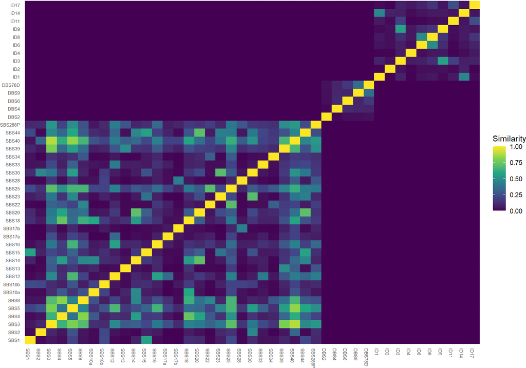

Note that:

- The diagonal elements of this matrix are all 1, since each signature is identical to itself
- The columns and rows are in the same order (i.e., column 1 corresponds to the same signature as row 1, etc.)
- The ordering of the signatures in the similarity matrix, `ESCC_sig_similarity`, matches the ordering in the relative abundance matrix, `ESCC_sig_activity`.

## 3.2 Visualize mutational signature activities

We can visualize these signature activities using the function `plot_signature_prop`, which generates a series of stacked bar plots. Each vertical bar corresponds to one sample (i.e., one row of `ESCC_sig_activity`).

Because `ESCC_sig_activity` contains metadata, we specify `K=43` so that only the rightmost 43 columns are treated as signature abundances. Specifying `group = "Country"` creates one panel for each country, while specifying `arrange = TRUE` reorders signatures vertically from most to least abundant and reorders samples horizontally by the abundances of their most abundant signatures.

Because `plot_signature_prop` returns a ggplot2 object, it can be modified with ggplot2 functions, such as `scale_color_manual` and `scale_fill_manual`.

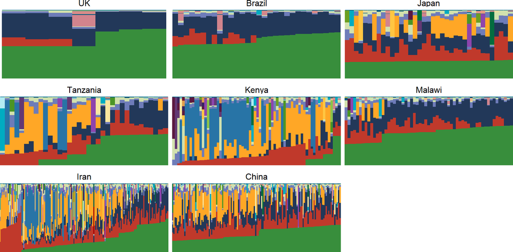

```r
plot_signature_prop(relab_matrix = ESCC_sig_activity,
              K = 43,
              group = "Country",
              arrange = TRUE) +
  scale_color_manual(values = all_sig_pal)  +
  scale_fill_manual(values = all_sig_pal)
```

```r
# all_sig_pal is a vector of hex color codes, each corresponding to
# one signature used in our paper.
# Below we show the first 6 entries as an example.
all_sig_pal[1:6]
```

```
#>     SBS40    SBS40a    SBS40b    SBS40c      SBS5      SBS1
#> "#2874A6" "#81A1C8" "#0E4384" "#2874A6" "#FFC642" "#C0392B"
```

We can also visualize the country-level mean signature activities with the function `plot_dots` in the *sigvar* R package.

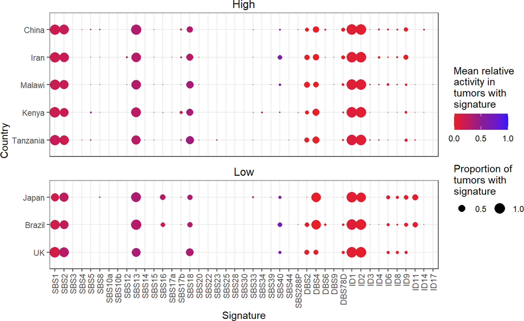

```r
plot_dots(sig_activity = ESCC_sig_activity,
          K = 43, group = "Country",
          facet = "Incidence_Level",
          pivot = TRUE)
```

## 3.3 Signature variability analysis

Signature variability analysis can be conducted in a single line of code:

```r
sva = sigvar(sig_activity = ESCC_sig_activity,
             K = 43,
             S = ESCC_sig_similarity,
             group = "Country")

knitr::kable(sva)
```

| Country | across_sample_heterogeneity | mean_within_sample_diversity |
| --- | --- | --- |
| Kenya | 0.1556304 | 0.6624312 |
| Iran | 0.1835807 | 0.6197756 |
| Tanzania | 0.1482450 | 0.6651016 |
| China | 0.1473591 | 0.6527459 |
| Japan | 0.1971177 | 0.6105965 |
| Malawi | 0.1717769 | 0.6378888 |
| Brazil | 0.1955283 | 0.6036918 |
| UK | 0.1765105 | 0.5973674 |

Signature variability analysis quantifies both the mean signature diversity within each sample, as well as the heterogeneity in signature activities across samples. Both variability statistics range between 0 and 1.

If we add to our SVA results a column corresponding to the incidence of each country, we are able to determine if signature heterogeneity or diversity are associated with ESCC incidence.

```r
sva_incidence = ESCC_sig_activity %>%
  transmute(Country = as.character(Country),
            Incidence_Level) %>%
  distinct %>%
  right_join(sva)

knitr::kable(sva_incidence)
```

| Country | Incidence_Level | across_sample_heterogeneity | mean_within_sample_diversity |
| --- | --- | --- | --- |
| Kenya | High | 0.1556304 | 0.6624312 |
| Iran | High | 0.1835807 | 0.6197756 |
| Tanzania | High | 0.1482450 | 0.6651016 |
| China | High | 0.1473591 | 0.6527459 |
| Japan | Low | 0.1971177 | 0.6105965 |
| Malawi | High | 0.1717769 | 0.6378888 |
| Brazil | Low | 0.1955283 | 0.6036918 |
| UK | Low | 0.1765105 | 0.5973674 |

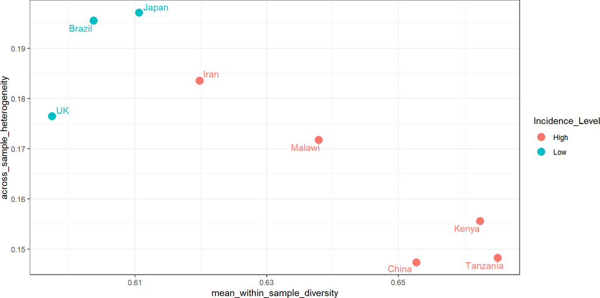

```r
ggplot(sva_incidence,
       aes(x = mean_within_sample_diversity,
           y = across_sample_heterogeneity,
           color = Incidence_Level)) +
  geom_point(size = 4) +
  ggrepel::geom_text_repel(aes(label = Country)) +
  theme_bw()
```

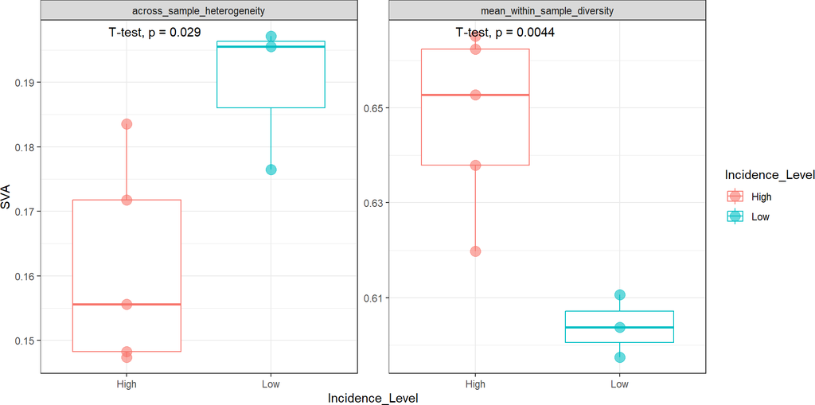

```r
ggplot(sva_incidence %>%
         pivot_longer(cols = c("across_sample_heterogeneity",
                               "mean_within_sample_diversity"),
                      names_to = "Statistic",
                      values_to = "SVA"),
       aes(x = Incidence_Level, y = SVA)) +
  geom_boxplot(aes(color = Incidence_Level)) +
  geom_point(aes(color = Incidence_Level), size = 4, alpha = 0.6) +
  facet_wrap(~ Statistic, scales = "free_y") +
  ggpubr::stat_compare_means(method = "t.test") +
  theme_bw()
```

We see that high-ESCC-incidence countries have more within-sample signature diversity and less across-sample heterogeneity than low-incidence countries.

## 3.4 Bootstrapping

When comparing one group of populations to another group of populations, like when comparing high- and low-incidence countries, we can use conventional statistical tests for comparing two distributions, such as Wilcoxon rank-sum tests and T-tests. However, when comparing the SVA results of just one population to another population (say we wanted to compare the SVA results of just Japan to those of just Kenya), we rely on a statistical method known as bootstrapping (implemented as `sigboot` in the *sigvar* R package).

We will demonstrate sigboot with an example comparing Japan ($n=37$ samples) to Kenya ($m=68$ samples). Bootstrapping proceeds in the following steps:

This procedure is implemented in the function `sigboot`, which can conduct many pairwise comparisons. In the below example, we generate 500 bootstrap replicates (`n_replicates = 500`) of the difference in SVA values between each country (`group = "Country"`) in our signature activity matrix (`relab_matrix = ESCC_sig_activity`). We account for the cosine similarity between signatures in each computation (`S = ESCC_sig_similarity`). Because bootstrapping is a random process, running the code multiple times would give slightly different results. Setting a random seed (`seed = 1`) makes this result repeatable. If you wish to perform a one-sided statistical test, you can specify `alternative = "lesser"` or `alternative = "greater"`; the default value is `alternative = "two.sided"`.

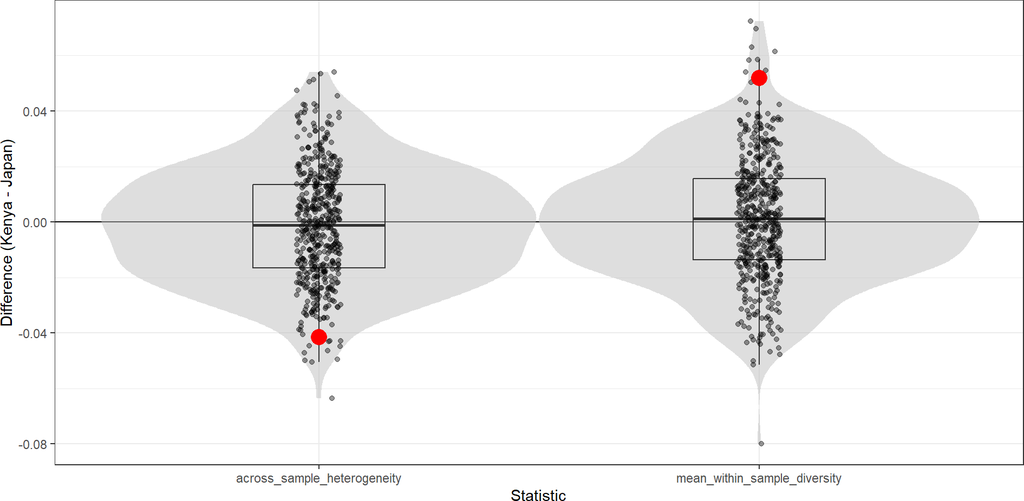

```r
comparison_boot = sigboot(sig_activity = ESCC_sig_activity %>%
                         filter(Country %in% c("Japan", "Kenya")),
                       K = 43,
                       group = "Country",
                       S = ESCC_sig_similarity,
                       n_replicates = 500,
                       seed = 1)

comparison_boot$bootstrap_distribution_plot
```

```r
comparison_boot$P_values
```

```
#>      group_1 group_2 across_sample_heterogeneity mean_within_sample_diversity
#> [1,] "Kenya" "Japan" "0.042"                     "0.018"
```

# 4 Conclusion

This concludes the tutorial on the *sigvar* R package for signature variability analysis. We hope you found it helpful! For guidance on specific functions, access the documentation by typing `?` into the R console (e.g., `?sigboot`). To see all available functions, type `?sigvar::`. For more details on signature variability analysis, see the paper [“Variability of mutational signatures is a footprint of carcinogens’’ by Morrison et al](https://doi.org/10.1101/2023.11.23.23298821). If you find a problem with the R package, please [open an issue on Github using this link](https://github.com/MaikeMorrison/sigvar/issues).